# Project3

### Helpful Functions for Tensorflow (little gems)

The following functions will be used with TensorFlow to help preprocess the data. They allow you to build the feature vector for a neural network.

(1) Encoding data:

- **encode_text_dummy** - Encode text fields as numeric, such as the iris species as a single field for each class. Three classes would become "0,0,1" "0,1,0" and "1,0,0". **Encode non-target features this way**. **(one hot encoding)**
- **encode_text_index** - Encode text fields to numeric, such as the iris species as a single numeric field as "0" "1" and "2". **Encode the target field for a classification this way**. **(label encoding)**

(2) Normalizing data:

- **encode_numeric_zscore** - Encode numeric values as a z-score. Neural networks deal well with "normalized" fields only.
- **encode_numeric_range** - Encode a column to a range between the given normalized_low and normalized_high.

(3) Dealing with missing data:

- **missing_median** - Fill all missing values with the median value.

(4) Removing outliers:

- **remove_outliers** - Remove outliers in a certain column with a value beyond X times SD

(5) Creating the **feature vector** and **target vector** that *** Tensorflow needs**. ***Notice that Tensorflow only takes Numpy array as input**

- **to_xy** - If all fields are numeric, this function can ***create X (feature matrix) and Y (response vector) *** in a format TensorFlow needs.

```python
from collections.abc import Sequence
from sklearn import preprocessing
import matplotlib.pyplot as plt
import numpy as np
import pandas as pd
import shutil
import os


# Encode text values to dummy variables(i.e. [1,0,0],[0,1,0],[0,0,1] for red,green,blue)
def encode_text_dummy(df, name):
    dummies = pd.get_dummies(df[name])
    for x in dummies.columns:
        dummy_name = "{}-{}".format(name, x)
        df[dummy_name] = dummies[x]
    df.drop(name, axis=1, inplace=True)


# Encode text values to indexes(i.e. [1],[2],[3] for red,green,blue).
def encode_text_index(df, name):
    le = preprocessing.LabelEncoder()
    df[name] = le.fit_transform(df[name])
    return le.classes_


# Encode a numeric column as zscores
def encode_numeric_zscore(df, name, mean=None, sd=None):
    if mean is None:
        mean = df[name].mean()

    if sd is None:
        sd = df[name].std()

    df[name] = (df[name] - mean) / sd


# Convert all missing values in the specified column to the median
def missing_median(df, name):
    med = df[name].median()
    df[name] = df[name].fillna(med)


# Convert all missing values in the specified column to the default
def missing_default(df, name, default_value):
    df[name] = df[name].fillna(default_value)


# Convert a Pandas dataframe to the x,y inputs that TensorFlow needs
def to_xy(df, target):
    result = []
    for x in df.columns:
        if x != target:
            result.append(x)
    # find out the type of the target column.
    target_type = df[target].dtypes
    target_type = target_type[0] if isinstance(target_type, Sequence) else target_type
    # Encode to int for classification, float otherwise. TensorFlow likes 32 bits.
    if target_type in (np.int64, np.int32):
        # Classification
        dummies = pd.get_dummies(df[target])
        return df[result].values.astype(np.float32), dummies.values.astype(np.float32)
    else:
        # Regression
        return df[result].values.astype(np.float32), df[target].values.astype(np.float32)

# Nicely formatted time string
def hms_string(sec_elapsed):
    h = int(sec_elapsed / (60 * 60))
    m = int((sec_elapsed % (60 * 60)) / 60)
    s = sec_elapsed % 60
    return "{}:{:>02}:{:>05.2f}".format(h, m, s)


# Regression chart.
def chart_regression(pred,y,sort=True):
    t = pd.DataFrame({'pred' : pred, 'y' : y.flatten()})
    if sort:
        t.sort_values(by=['y'],inplace=True)
    a = plt.plot(t['y'].tolist(),label='expected')
    b = plt.plot(t['pred'].tolist(),label='prediction')
    plt.ylabel('output')
    plt.legend()
    plt.show()

# Remove all rows where the specified column is +/- sd standard deviations
def remove_outliers(df, name, sd):
    drop_rows = df.index[(np.abs(df[name] - df[name].mean()) >= (sd * df[name].std()))]
    df.drop(drop_rows, axis=0, inplace=True)


# Encode a column to a range between normalized_low and normalized_high.
def encode_numeric_range(df, name, normalized_low=-1, normalized_high=1,
                         data_low=None, data_high=None):
    if data_low is None:
        data_low = min(df[name])
        data_high = max(df[name])

    df[name] = ((df[name] - data_low) / (data_high - data_low)) * (normalized_high - normalized_low) + normalized_low
```

### Confusion Matrix and ROC Curve

```python
%matplotlib inline
import matplotlib.pyplot as plt
from sklearn.metrics import roc_curve, auc

# Plot a confusion matrix.
# cm is the confusion matrix, names are the names of the classes.
def plot_confusion_matrix(cm, names, title='Confusion matrix', cmap=plt.cm.Blues):
    plt.imshow(cm, interpolation='nearest', cmap=cmap)
    plt.title(title)
    plt.colorbar()
    tick_marks = np.arange(len(names))
    plt.xticks(tick_marks, names, rotation=45)
    plt.yticks(tick_marks, names)
    plt.tight_layout()
    plt.ylabel('True label')
    plt.xlabel('Predicted label')


# Plot an ROC. pred - the predictions, y - the expected output.
def plot_roc(pred,y):
    fpr, tpr, thresholds = roc_curve(y, pred)
    roc_auc = auc(fpr, tpr)

    plt.figure()
    plt.plot(fpr, tpr, label='ROC curve (area = %0.2f)' % roc_auc)
    plt.plot([0, 1], [0, 1], 'k--')
    plt.xlim([0.0, 1.0])
    plt.ylim([0.0, 1.05])
    plt.xlabel('False Positive Rate')
    plt.ylabel('True Positive Rate')
    plt.title('Receiver Operating Characteristic (ROC)')
    plt.legend(loc="lower right")
    plt.show()
```

## Import data

```python
filename_read = os.path.join("Houses dataset/HousesInfo.txt")

cols=["Bedrooms","Bathrooms","area","zipcode","price"]

df = pd.read_csv(filename_read , sep=" ", header=None , names=cols)

df['id'] = range(len(df))
df.head()
```

|  | Bedrooms | Bathrooms | area | zipcode | price | id |
| --- | --- | --- | --- | --- | --- | --- |
| 0 | 4 | 4.0 | 4053 | 85255 | 869500 | 0 |
| 1 | 4 | 3.0 | 3343 | 36372 | 865200 | 1 |
| 2 | 3 | 4.0 | 3923 | 85266 | 889000 | 2 |
| 3 | 5 | 5.0 | 4022 | 85262 | 910000 | 3 |
| 4 | 3 | 4.0 | 4116 | 85266 | 971226 | 4 |

## Data Preprocessing

### Remove outliers

Keep the houses with a price between 100K and 900K

```python
condition = (df['price'] > 100000) & (df['price'] < 900000)
df = df[condition]
df
```

|  | Bedrooms | Bathrooms | area | zipcode | price | id |
| --- | --- | --- | --- | --- | --- | --- |
| 0 | 4 | 4.0 | 4053 | 85255 | 869500 | 0 |
| 1 | 4 | 3.0 | 3343 | 36372 | 865200 | 1 |
| 2 | 3 | 4.0 | 3923 | 85266 | 889000 | 2 |
| 6 | 3 | 4.0 | 2544 | 85262 | 799000 | 6 |
| 10 | 5 | 5.0 | 4829 | 85266 | 519200 | 10 |
| ... | ... | ... | ... | ... | ... | ... |
| 530 | 5 | 2.0 | 2066 | 94531 | 399900 | 530 |
| 531 | 4 | 3.5 | 9536 | 94531 | 460000 | 531 |
| 532 | 3 | 2.0 | 2014 | 94531 | 407000 | 532 |
| 533 | 4 | 3.0 | 2312 | 94531 | 419000 | 533 |
| 534 | 5 | 3.0 | 3796 | 94531 | 615000 | 534 |

405 rows × 6 columns

### Encode categorical features and normalize numeric features.

```python
numeric = ['Bedrooms', 'Bathrooms', 'area']

encode_text_dummy(df, 'zipcode')

for numCat in numeric:
    encode_numeric_zscore(df, numCat)
```

```python
df
```

|  | Bedrooms | Bathrooms | area | price | id | zipcode-36372 | zipcode-60002 | zipcode-60016 | zipcode-60046 | zipcode-62025 | ... | zipcode-93314 | zipcode-93446 | zipcode-93510 | zipcode-94501 | zipcode-94531 | zipcode-94565 | zipcode-94568 | zipcode-95220 | zipcode-96019 | zipcode-98021 |
| --- | --- | --- | --- | --- | --- | --- | --- | --- | --- | --- | --- | --- | --- | --- | --- | --- | --- | --- | --- | --- | --- |
| 0 | 0.520436 | 1.635628 | 1.539241 | 869500 | 0 | False | False | False | False | False | ... | False | False | False | False | False | False | False | False | False | False |
| 1 | 0.520436 | 0.494001 | 0.916083 | 865200 | 1 | True | False | False | False | False | ... | False | False | False | False | False | False | False | False | False | False |
| 2 | -0.372685 | 1.635628 | 1.425142 | 889000 | 2 | False | False | False | False | False | ... | False | False | False | False | False | False | False | False | False | False |
| 6 | -0.372685 | 1.635628 | 0.214810 | 799000 | 6 | False | False | False | False | False | ... | False | False | False | False | False | False | False | False | False | False |
| 10 | 1.413556 | 2.777256 | 2.220327 | 519200 | 10 | False | False | False | False | False | ... | False | False | False | False | False | False | False | False | False | False |
| ... | ... | ... | ... | ... | ... | ... | ... | ... | ... | ... | ... | ... | ... | ... | ... | ... | ... | ... | ... | ... | ... |
| 530 | 1.413556 | -0.647627 | -0.204724 | 399900 | 530 | False | False | False | False | False | ... | False | False | False | False | True | False | False | False | False | False |
| 531 | 0.520436 | 1.064815 | 6.351603 | 460000 | 531 | False | False | False | False | False | ... | False | False | False | False | True | False | False | False | False | False |
| 532 | -0.372685 | -0.647627 | -0.250364 | 407000 | 532 | False | False | False | False | False | ... | False | False | False | False | True | False | False | False | False | False |
| 533 | 0.520436 | 0.494001 | 0.011187 | 419000 | 533 | False | False | False | False | False | ... | False | False | False | False | True | False | False | False | False | False |
| 534 | 1.413556 | 0.494001 | 1.313675 | 615000 | 534 | False | False | False | False | False | ... | False | False | False | False | True | False | False | False | False | False |

405 rows × 45 columns

```python
df.shape
```

```
(405, 45)
```

### Handling the images

```python
## Bathroom.jpg
import glob


new_images=[]
for number in range(1, 536):
    for path in glob.glob("Houses dataset/" + str(number) + "_bathroom.jpg"):
        if os.path.isfile(path):
            new_images.append(path)
```

```python
new_images
```

```python
img= pd.DataFrame(new_images,columns = ['bathroom_img'])
```

```python
## bedroom images
bedroom_images = []
for number in range(1, 536):
    for path in glob.glob("Houses dataset/" + str(number) + "_bedroom.jpg"):
        if os.path.isfile(path):
            bedroom_images.append(path)
```

```python
img['bedroom_img']=bedroom_images
```

```python
## front of house images
frontal_images = []
for number in range(1, 536):
    for path in glob.glob("Houses dataset/" + str(number) + "_frontal.jpg"):
        if os.path.isfile(path):
            frontal_images.append(path)

img['frontal_img']=frontal_images
```

```python
## kitchen images
kitchen_images = []
for number in range(1, 536):
    for path in glob.glob("Houses dataset/" + str(number) + "_kitchen.jpg"):
        if os.path.isfile(path):
            kitchen_images.append(path)

img['kitchen_img']=kitchen_images
```

```python
img['id'] = range(len(img))
```

```python
img.head()
```

|  | bathroom_img | bedroom_img | frontal_img | kitchen_img | id |
| --- | --- | --- | --- | --- | --- |
| 0 | Houses dataset/1_bathroom.jpg | Houses dataset/1_bedroom.jpg | Houses dataset/1_frontal.jpg | Houses dataset/1_kitchen.jpg | 0 |
| 1 | Houses dataset/2_bathroom.jpg | Houses dataset/2_bedroom.jpg | Houses dataset/2_frontal.jpg | Houses dataset/2_kitchen.jpg | 1 |
| 2 | Houses dataset/3_bathroom.jpg | Houses dataset/3_bedroom.jpg | Houses dataset/3_frontal.jpg | Houses dataset/3_kitchen.jpg | 2 |
| 3 | Houses dataset/4_bathroom.jpg | Houses dataset/4_bedroom.jpg | Houses dataset/4_frontal.jpg | Houses dataset/4_kitchen.jpg | 3 |
| 4 | Houses dataset/5_bathroom.jpg | Houses dataset/5_bedroom.jpg | Houses dataset/5_frontal.jpg | Houses dataset/5_kitchen.jpg | 4 |

```python
img.shape
```

```
(535, 5)
```

```python
img = img[img['id'].isin(df['id'])]
```

```python
df = df.drop('id', axis=1)
img = img.drop('id', axis=1)
```

```python
df.shape
```

```
(405, 44)
```

```python
img.shape
```

```
(405, 4)
```

### Concantenate 4 images from each house into one image

```python
import cv2


images_output=[]
for row_index,row in img.iterrows():
            inputImages=[]
            outputImage = np.zeros((128, 128, 3), dtype="uint8")
            image_temp1 = cv2.imread(row.bathroom_img)
            image1 = cv2.resize(image_temp1, (64 , 64))

            image_temp2 = cv2.imread(row.bedroom_img)
            image2 = cv2.resize(image_temp2, (64 , 64))

            image_temp3 = cv2.imread(row.frontal_img)
            image3 = cv2.resize(image_temp3, (64 , 64))

            image_temp4 = cv2.imread(row.kitchen_img)
            image4 = cv2.resize(image_temp4, (64 , 64))

            inputImages.append(image1)
            inputImages.append(image2)
            inputImages.append(image3)
            inputImages.append(image4)

            outputImage[0:64, 0:64] = inputImages[0]
            outputImage[0:64, 64:128] = inputImages[1]
            outputImage[64:128, 64:128] = inputImages[2]
            outputImage[64:128, 0:64] = inputImages[3]


            images_output.append(outputImage)
```

```python
img_arr=np.asarray(images_output)
img_arr.shape
```

```
(405, 128, 128, 3)
```

```python
df.shape
```

```
(405, 44)
```

## Split data into training and testing set

```python
from sklearn.model_selection import train_test_split
x = np.asarray(df.drop('price', axis=1), dtype='float32')
y = np.asarray(df['price'], dtype='float32')
x_train_text, x_test_text, y_train_text, y_test_text = train_test_split(x, y, test_size=0.20, random_state=42)
x_train_image, x_test_image = train_test_split(img_arr, test_size=0.20, random_state=42)
```

## Train the model

```python
from tensorflow.keras.layers import Dense, Activation
from tensorflow.keras.callbacks import EarlyStopping
from tensorflow.keras.callbacks import ModelCheckpoint
from tensorflow.keras.layers import Input
from tensorflow.keras.utils import plot_model
from tensorflow.keras.models import Model
from tensorflow.keras.layers import Flatten
from tensorflow.keras.layers import Conv2D
from tensorflow.keras.layers import MaxPooling2D
from tensorflow.keras.layers import concatenate

# Define ModelCheckpoint outside the loop
checkpointer = ModelCheckpoint(filepath="dnn/best_weights.hdf5", verbose=0, save_best_only=True) # save best model

for i in range(10):
    print(i)

    # first input model for the text
    visible1 = Input(shape=(43,))
    flat = Flatten()(visible1)
    dense1 = Dense(250, activation='relu')(flat)
    dense2 = Dense(125, activation='relu')(dense1)
    dense3 = Dense(75, activation='relu')(dense2)
    text_model = Dense(25, activation='relu')(dense3)



    # second input model
    visible2 = Input(shape=(128,128,3))
    conv21 = Conv2D(64, kernel_size=4, activation='relu')(visible2)
    pool21 = MaxPooling2D(pool_size=(2, 2))(conv21)
    conv22 = Conv2D(32, kernel_size=4, activation='relu')(pool21)
    pool22 = MaxPooling2D(pool_size=(2, 2))(conv22)
    conv23 = Conv2D(16, kernel_size=4, activation='relu')(pool22)
    pool23 = MaxPooling2D(pool_size=(2, 2))(conv23)
    img_model = Flatten()(pool23)

    # merge input models
    merge = concatenate([text_model, img_model])


    # interpretation model
    hidden1 = Dense(50, activation='relu')(merge)
    hidden2 = Dense(25, activation='relu')(hidden1)
    hidden3 = Dense(25, activation='relu')(hidden2)
    output = Dense(1, activation='linear')(hidden3)


    model = Model(inputs=[visible1, visible2], outputs=output)
    model.compile( optimizer='adam', loss='mean_squared_error')

    monitor = EarlyStopping(monitor='val_loss', min_delta=1e-3, patience=10, verbose=1, mode='auto')

    model.fit([x_train_text, x_train_image], y_train_text, validation_data=([x_test_text, x_test_image], y_test_text), callbacks=[monitor, checkpointer], verbose=2, epochs=1000)



print('Training finished...Loading the best model')
print()
model.load_weights('dnn/best_weights.hdf5') # load weights from best model
```

```
Model: "model_19"
__________________________________________________________________________________________________
 Layer (type)                   Output Shape         Param #     Connected to
==================================================================================================
 input_40 (InputLayer)          [(None, 128, 128, 3  0           []
                                )]

 conv2d_57 (Conv2D)             (None, 125, 125, 64  3136        ['input_40[0][0]']
                                )

 input_39 (InputLayer)          [(None, 43)]         0           []

 max_pooling2d_57 (MaxPooling2D  (None, 62, 62, 64)  0           ['conv2d_57[0][0]']
 )

 flatten_38 (Flatten)           (None, 43)           0           ['input_39[0][0]']

 conv2d_58 (Conv2D)             (None, 59, 59, 32)   32800       ['max_pooling2d_57[0][0]']

 dense_152 (Dense)              (None, 250)          11000       ['flatten_38[0][0]']

 max_pooling2d_58 (MaxPooling2D  (None, 29, 29, 32)  0           ['conv2d_58[0][0]']
 )

 dense_153 (Dense)              (None, 125)          31375       ['dense_152[0][0]']

 conv2d_59 (Conv2D)             (None, 26, 26, 16)   8208        ['max_pooling2d_58[0][0]']

 dense_154 (Dense)              (None, 75)           9450        ['dense_153[0][0]']

 max_pooling2d_59 (MaxPooling2D  (None, 13, 13, 16)  0           ['conv2d_59[0][0]']
 )

 dense_155 (Dense)              (None, 25)           1900        ['dense_154[0][0]']

 flatten_39 (Flatten)           (None, 2704)         0           ['max_pooling2d_59[0][0]']

 concatenate_19 (Concatenate)   (None, 2729)         0           ['dense_155[0][0]',
                                                                  'flatten_39[0][0]']

 dense_156 (Dense)              (None, 50)           136500      ['concatenate_19[0][0]']

 dense_157 (Dense)              (None, 25)           1275        ['dense_156[0][0]']

 dense_158 (Dense)              (None, 25)           650         ['dense_157[0][0]']

 dense_159 (Dense)              (None, 1)            26          ['dense_158[0][0]']

==================================================================================================
Total params: 236,320
Trainable params: 236,320
Non-trainable params: 0
__________________________________________________________________________________________________
None
```

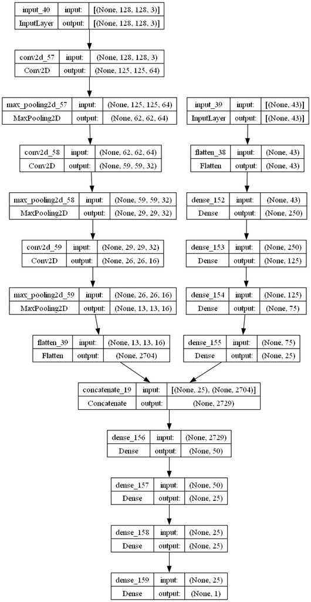

```python
# summarize layers
print(model.summary())
# plot graph
plot_model(model, show_shapes=True)
```

## Test the model

```
Score (RMSE): 115049.5859375
```

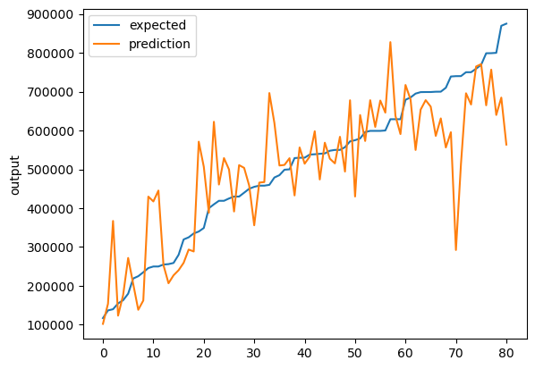

```python
from sklearn import metrics


pred = model.predict([x_test_text, x_test_image])

score = np.sqrt(metrics.mean_squared_error(pred,y_test_text))
print("Score (RMSE): {}".format(score))

# Plot the chart
chart_regression(pred.flatten(), y_test_text, sort= True)
```

# Additional Features

Is there a better way to take advantage of zipcode?

```python
numeric = ['Bedrooms', 'Bathrooms', 'area']

for numCat in numeric:
    encode_numeric_zscore(df, numCat)
```

### Remove zipcode

```python
df = df.drop('zipcode', axis=1)
df = df.drop('id', axis=1)
```

```python
df
```

|  | Bedrooms | Bathrooms | area | price |
| --- | --- | --- | --- | --- |
| 0 | 0.520436 | 1.635628 | 1.539241 | 869500 |
| 1 | 0.520436 | 0.494001 | 0.916083 | 865200 |
| 2 | -0.372685 | 1.635628 | 1.425142 | 889000 |
| 6 | -0.372685 | 1.635628 | 0.214810 | 799000 |
| 10 | 1.413556 | 2.777256 | 2.220327 | 519200 |
| ... | ... | ... | ... | ... |
| 530 | 1.413556 | -0.647627 | -0.204724 | 399900 |
| 531 | 0.520436 | 1.064815 | 6.351603 | 460000 |
| 532 | -0.372685 | -0.647627 | -0.250364 | 407000 |
| 533 | 0.520436 | 0.494001 | 0.011187 | 419000 |
| 534 | 1.413556 | 0.494001 | 1.313675 | 615000 |

405 rows × 4 columns

```python
from sklearn.model_selection import train_test_split
x = np.asarray(df.drop('price', axis=1), dtype='float32')
y = np.asarray(df['price'], dtype='float32')
x_train_text, x_test_text, y_train_text, y_test_text = train_test_split(x, y, test_size=0.20, random_state=42)
x_train_image, x_test_image = train_test_split(img_arr, test_size=0.20, random_state=42)
```

```python
x_train_text.shape
```

```
(324, 3)
```

```python
from tensorflow.keras.layers import Dense, Activation
from tensorflow.keras.callbacks import EarlyStopping
from tensorflow.keras.callbacks import ModelCheckpoint
from tensorflow.keras.layers import Input
from tensorflow.keras.utils import plot_model
from tensorflow.keras.models import Model
from tensorflow.keras.layers import Flatten
from tensorflow.keras.layers import Conv2D
from tensorflow.keras.layers import MaxPooling2D
from tensorflow.keras.layers import concatenate

# Define ModelCheckpoint outside the loop
checkpointer = ModelCheckpoint(filepath="dnn/best_weights.hdf5", verbose=0, save_best_only=True) # save best model

for i in range(10):
    print(i)

    # first input model for the text
    visible1 = Input(shape=(3,))
    flat = Flatten()(visible1)
    dense1 = Dense(250, activation='relu')(flat)
    dense2 = Dense(125, activation='relu')(dense1)
    dense3 = Dense(75, activation='relu')(dense2)
    text_model = Dense(25, activation='relu')(dense3)



    # second input model
    visible2 = Input(shape=(128,128,3))
    conv21 = Conv2D(64, kernel_size=4, activation='relu')(visible2)
    pool21 = MaxPooling2D(pool_size=(2, 2))(conv21)
    conv22 = Conv2D(32, kernel_size=4, activation='relu')(pool21)
    pool22 = MaxPooling2D(pool_size=(2, 2))(conv22)
    conv23 = Conv2D(16, kernel_size=4, activation='relu')(pool22)
    pool23 = MaxPooling2D(pool_size=(2, 2))(conv23)
    img_model = Flatten()(pool23)

    # merge input models
    merge = concatenate([text_model, img_model])


    # interpretation model
    hidden1 = Dense(50, activation='relu')(merge)
    hidden2 = Dense(25, activation='relu')(hidden1)
    hidden3 = Dense(25, activation='relu')(hidden2)
    output = Dense(1, activation='linear')(hidden3)


    model = Model(inputs=[visible1, visible2], outputs=output)
    model.compile( optimizer='adam', loss='mean_squared_error')

    monitor = EarlyStopping(monitor='val_loss', min_delta=1e-3, patience=10, verbose=1, mode='auto')

    model.fit([x_train_text, x_train_image], y_train_text, validation_data=([x_test_text, x_test_image], y_test_text), callbacks=[monitor, checkpointer], verbose=2, epochs=1000)



print('Training finished...Loading the best model')
print()
model.load_weights('dnn/best_weights.hdf5') # load weights from best model
```

```
Score (RMSE): 181072.8125
```

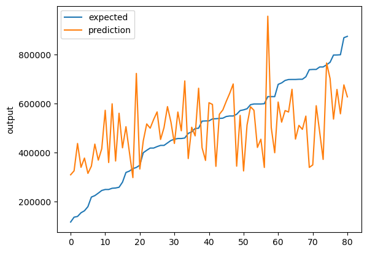

```python
from sklearn import metrics


pred = model.predict([x_test_text, x_test_image])

score = np.sqrt(metrics.mean_squared_error(pred,y_test_text))
print("Score (RMSE): {}".format(score))

# Plot the chart
chart_regression(pred.flatten(), y_test_text, sort= True)
```

```python
zipcode = pd.DataFrame(df['zipcode'],columns = ['zipcode'])
```

```python
df = df.drop('zipcode', axis=1)
df = df.drop('id', axis=1)
```

[output not shown]

405 rows × 4 columns

### Treat zipcode as a separate input channel

```python
numeric = ['Bedrooms', 'Bathrooms', 'area']

for numCat in numeric:
    encode_numeric_zscore(df, numCat)

encode_text_dummy(zipcode, 'zipcode')
```

```python
from sklearn.model_selection import train_test_split
x = np.asarray(df.drop('price', axis=1), dtype='float32')
y = np.asarray(df['price'], dtype='float32')
array_zipcode = np.asanyarray(zipcode)
x_train_text, x_test_text, y_train_text, y_test_text = train_test_split(x, y, test_size=0.20, random_state=42)
x_train_zip, x_test_zip = train_test_split(array_zipcode, test_size=0.20, random_state=42)
x_train_image, x_test_image = train_test_split(img_arr, test_size=0.20, random_state=42)
```

```python
from tensorflow.keras.layers import Dense, Activation
from tensorflow.keras.callbacks import EarlyStopping
from tensorflow.keras.callbacks import ModelCheckpoint
from tensorflow.keras.layers import Input
from tensorflow.keras.utils import plot_model
from tensorflow.keras.models import Model
from tensorflow.keras.layers import Flatten
from tensorflow.keras.layers import Conv2D
from tensorflow.keras.layers import MaxPooling2D
from tensorflow.keras.layers import concatenate

# Define ModelCheckpoint outside the loop
checkpointer = ModelCheckpoint(filepath="dnn/best_weights.hdf5", verbose=0, save_best_only=True) # save best model

for i in range(10):
    print(i)

    # first input model for the text
    visible1 = Input(shape=(3,))
    flat = Flatten()(visible1)
    dense1 = Dense(250, activation='relu')(flat)
    dense2 = Dense(125, activation='relu')(dense1)
    dense3 = Dense(75, activation='relu')(dense2)
    text_model = Dense(25, activation='relu')(dense3)



    # second input model
    visible2 = Input(shape=(128,128,3))
    conv21 = Conv2D(64, kernel_size=4, activation='relu')(visible2)
    pool21 = MaxPooling2D(pool_size=(2, 2))(conv21)
    conv22 = Conv2D(32, kernel_size=4, activation='relu')(pool21)
    pool22 = MaxPooling2D(pool_size=(2, 2))(conv22)
    conv23 = Conv2D(16, kernel_size=4, activation='relu')(pool22)
    pool23 = MaxPooling2D(pool_size=(2, 2))(conv23)
    img_model = Flatten()(pool23)

    # third input model for the text
    visible3 = Input(shape=(40,))
    flat = Flatten()(visible3)
    dense1 = Dense(250, activation='relu')(flat)
    dense2 = Dense(125, activation='relu')(dense1)
    dense3 = Dense(75, activation='relu')(dense2)
    zipcode_model = Dense(25, activation='relu')(dense3)

    # merge input models
    merge = concatenate([text_model, img_model, zipcode_model])


    # interpretation model
    hidden1 = Dense(50, activation='relu')(merge)
    hidden2 = Dense(25, activation='relu')(hidden1)
    hidden3 = Dense(25, activation='relu')(hidden2)
    output = Dense(1, activation='linear')(hidden3)


    model = Model(inputs=[visible1, visible2, visible3], outputs=output)
    model.compile( optimizer='adam', loss='mean_squared_error')

    monitor = EarlyStopping(monitor='val_loss', min_delta=1e-3, patience=10, verbose=1, mode='auto')

    model.fit([x_train_text, x_train_image, x_train_zip], y_train_text, validation_data=([x_test_text, x_test_image, x_test_zip], y_test_text), callbacks=[monitor, checkpointer], verbose=2, epochs=1000)



print('Training finished...Loading the best model')
print()
model.load_weights('dnn/best_weights.hdf5') # load weights from best model
```

```
Model: "model_125"
__________________________________________________________________________________________________
 Layer (type)                   Output Shape         Param #     Connected to
==================================================================================================
 input_272 (InputLayer)         [(None, 128, 128, 3  0           []
                                )]

 conv2d_375 (Conv2D)            (None, 125, 125, 64  3136        ['input_272[0][0]']
                                )

 input_271 (InputLayer)         [(None, 3)]          0           []

 max_pooling2d_375 (MaxPooling2  (None, 62, 62, 64)  0           ['conv2d_375[0][0]']
 D)

 input_273 (InputLayer)         [(None, 40)]         0           []

 flatten_270 (Flatten)          (None, 3)            0           ['input_271[0][0]']

 conv2d_376 (Conv2D)            (None, 59, 59, 32)   32800       ['max_pooling2d_375[0][0]']

 flatten_272 (Flatten)          (None, 40)           0           ['input_273[0][0]']

 dense_1080 (Dense)             (None, 250)          1000        ['flatten_270[0][0]']

 max_pooling2d_376 (MaxPooling2  (None, 29, 29, 32)  0           ['conv2d_376[0][0]']
 D)

 dense_1084 (Dense)             (None, 250)          10250       ['flatten_272[0][0]']

 dense_1081 (Dense)             (None, 125)          31375       ['dense_1080[0][0]']

 conv2d_377 (Conv2D)            (None, 26, 26, 16)   8208        ['max_pooling2d_376[0][0]']

 dense_1085 (Dense)             (None, 125)          31375       ['dense_1084[0][0]']

 dense_1082 (Dense)             (None, 75)           9450        ['dense_1081[0][0]']

 max_pooling2d_377 (MaxPooling2  (None, 13, 13, 16)  0           ['conv2d_377[0][0]']
 D)
```

[output cut: 12 more lines]

```

 dense_1088 (Dense)             (None, 50)           137750      ['concatenate_125[0][0]']

 dense_1089 (Dense)             (None, 25)           1275        ['dense_1088[0][0]']

 dense_1090 (Dense)             (None, 25)           650         ['dense_1089[0][0]']

 dense_1091 (Dense)             (None, 1)            26          ['dense_1090[0][0]']

==================================================================================================
Total params: 280,545
Trainable params: 280,545
Non-trainable params: 0
__________________________________________________________________________________________________
None
```

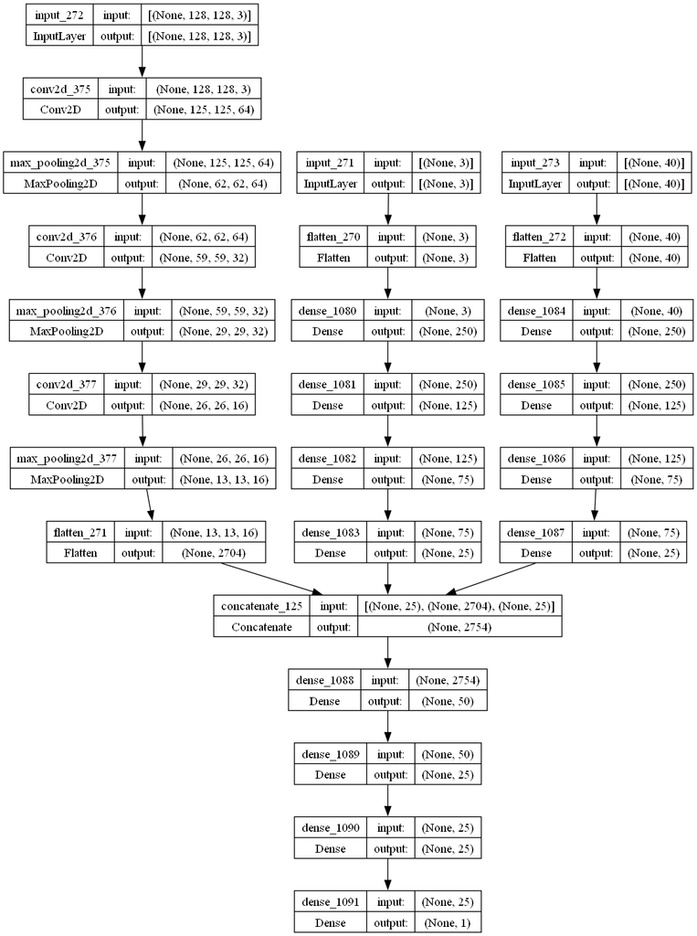

```python
# summarize layers
print(model.summary())
# plot graph
plot_model(model, show_shapes=True)
```

```
Score (RMSE): 114855.4453125
```

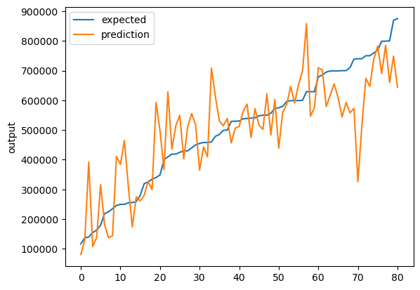

```python
from sklearn import metrics


pred = model.predict([x_test_text, x_test_image, x_test_zip])

score = np.sqrt(metrics.mean_squared_error(pred,y_test_text))
print("Score (RMSE): {}".format(score))

# Plot the chart
chart_regression(pred.flatten(), y_test_text, sort= True)
```